# Práctica 2.

#### by David Rivero Berrocoso.

the goal & the objective of this practice may be checked in the README document linked in this directory.

#### Índice:

0. Dataset & Dictionary Loading

1. Problem to solve and Dataset description.

2. EDA 2.1 Data types identification 2.2 Duplicates columns identifications 2.3 Target variable identification 2.4 Missing values processing 2.5 Identification of variables 2.6 Outliers 2.7 Correlations 2.8 Variables representation Numerical variables representation Categorical variables representation

3. Objectives To Model 3.1 Variable transformation. 3.2 Missing values transformation 3.3 Categorical variables encoding

4. For the target variable (Modeling). 4.1 Splitting into Train & Test. 4.2 Data Augmentation: Smote 4.3 Data Scaling: MinMax Scaler 4.4 Models Linear model Regression + Lasso Generalized Linear Models (GLM) Support Vector Machine (SVM) Random Forest XGBBoost LightGBM Other models 4.5 Best Model Selection XGBBoost Classifier ROC Curve

5 Interpretability 5.1 Feature importance Permutation Based Feature importance Partial Dependence Plot 5.2 Explainability

```python
#we import all the packages

import random
import pandas as pd
import numpy as np
import matplotlib.pyplot as plt
import seaborn as sns

from scipy.stats import chi2_contingency
import warnings
warnings.filterwarnings('ignore')
from sklearn.preprocessing import OneHotEncoder
from sklearn.model_selection import KFold
from sklearn.metrics import accuracy_score, roc_auc_score, confusion_matrix, classification_report, roc_curve, precision_recall_curve
import joblib
from eli5 import explain_weights
from eli5.sklearn import PermutationImportance
from sklearn.ensemble import RandomForestClassifier
from sklearn.model_selection import cross_val_score
from pdpbox import pdp, get_dataset, info_plots
from matplotlib.pyplot import figure
from sklearn.inspection import permutation_importance
```

```python
def dame_variables_categoricas(dataset=None):
    if dataset is None:
        print(u'\nFaltan argumentos por pasar a la función')
        return 1
    lista_variables_categoricas = []
    for i in dataset.columns:
        if (dataset[i].dtype!=float) & (dataset[i].dtype!=int):
            unicos = int(len(np.unique(dataset[i].dropna(axis=0, how='all'))))
            if unicos < 8:
                lista_variables_categoricas.append(i)
    return lista_variables_categoricas

def dame_variables_numericas(dataset=None):
    if dataset is None:
        print(u'\nFaltan argumentos por pasar a la función')
        return 1
    lista_variables_numericas = []
    for i in dataset.columns:
        if (dataset[i].dtype=='float64') or (dataset[i].dtype=='int64') :
            unicos = int(len(np.unique(dataset[i].dropna(axis=0, how='all'))))
            if unicos >3:
                lista_variables_numericas.append(i)
    return lista_variables_numericas

def get_deviation_of_mean_perc(pd_loan, list_var_continuous, target, multiplier):
    pd_final = pd.DataFrame()

    for i in list_var_continuous:

        series_mean = pd_loan[i].mean()
        series_std = pd_loan[i].std()
        std_amp = multiplier * series_std
        left = series_mean - std_amp
        right = series_mean + std_amp
        size_s = pd_loan[i].size

        perc_goods = pd_loan[i][(pd_loan[i] >= left) & (pd_loan[i] <= right)].size/size_s
        perc_excess = pd_loan[i][(pd_loan[i] < left) | (pd_loan[i] > right)].size/size_s

        if perc_excess>0:
            pd_concat_percent = pd.DataFrame(pd_loan[target][(pd_loan[i] < left) | (pd_loan[i] > right)]\
                                            .value_counts(normalize=True).reset_index()).T
            #pd_concat_percent.columns = [pd_concat_percent.iloc[0,0],
            #                            pd_concat_percent.iloc[0,1]]
            pd_concat_percent = pd_concat_percent.drop('index',axis=0)
            pd_concat_percent['variable'] = i
            pd_concat_percent['sum_outlier_values'] = pd_loan[i][(pd_loan[i] < left) | (pd_loan[i] > right)].size
            pd_concat_percent['porcentaje_sum_null_values'] = perc_excess
            pd_final = pd.concat([pd_final, pd_concat_percent], axis=0).reset_index(drop=True)

    if pd_final.empty:
        print('No existen variables con valores nulos')

    return pd_final

def duplicate_columns(frame):
    groups = frame.columns.to_series().groupby(frame.dtypes).groups
    dups = []

    for t, v in groups.items():

        cs = frame[v].columns
        vs = frame[v]
        lcs = len(cs)

        for i in range(lcs):
            ia = vs.iloc[:,i].values
            for j in range(i+1, lcs):
                ja = vs.iloc[:,j].values
                if np.array_equal(ia, ja):
                    dups.append(cs[i])
                    break
    return dups


def cramers_V(var1,var2) : #función toma 2 argumentos: variable 1 y variable 2
    crosstab =np.array(pd.crosstab(var1,var2, rownames=None, colnames=None)) #creamos una tabla de contingencia
    stat = chi2_contingency(crosstab)[0] #trabajamos sobre un chi square test.
    obs = np.sum(crosstab) #sumamos las observaciones relevantes
    mini = min(crosstab.shape)-1 #formula para la V de cramer.
    return (stat/(obs*mini))

def evaluate_model(ytest, ypred, ypred_proba = None):
    if ypred_proba is not None:
        print('ROC-AUC score of the model: {}'.format(roc_auc_score(ytest, ypred_proba[:, 1])))
    print('Accuracy of the model: {}\n'.format(accuracy_score(ytest, ypred)))
    print('Classification report: \n{}\n'.format(classification_report(ytest, ypred)))
    print('Confusion matrix: \n{}\n'.format(confusion_matrix(ytest, ypred)))

def matriz_confusion(conf_matrix):
    sns.heatmap(conf_matrix, annot=True, fmt=".3f", linewidths=.5, square = True, cmap = 'Blues_r')
```

#### 0. Dataset & Dictionary Loading

```python
data_raw = pd.read_csv('..\data\\raw\Original_dataset_payments_fraud.csv', sep=';')
data_raw.dtypes
```

```
step                  int64
type                 object
amount              float64
gender               object
device               object
connection_time      object
nameOrig             object
race                 object
oldbalanceOrg       float64
age                   int64
newbalanceOrig      float64
zone                 object
user_number           int64
nameDest             object
user_connections      int64
security_alert        int64
oldbalanceDest      float64
newbalanceDest      float64
isFraud               int64
dtype: object
```

```python
my_dictionary = pd.read_excel('..\data\\raw\dictionary.xlsx', header=None)
my_dictionary.columns = ('Name', 'Description')
my_dictionary
```

|  | Name | Description |
| --- | --- | --- |
| 0 | step | unidad de tiempo, 1 = 1 hora |
| 1 | type | tipo |
| 2 | amount | cantidad |
| 3 | gender | género (informado por el cliente) |
| 4 | device | tipo del dispositivo que inicio la transacción |
| 5 | connection_time | segundos que tardan en llegar los datos desde... |
| 6 | nameOrig | identificador del cliente que inicia la trans... |
| 7 | race | raza |
| 8 | oldbalanceOrg | saldo antes de la transacción |
| 9 | age | edad estimada |
| 10 | newbalanceOrig | saldo después |
| 11 | nameDest | receptor de la transacción |
| 12 | user_connections | conexiones del mismo usuario ese día |
| 13 | security_alert | si existía una alerta de seguridad ese día em... |
| 14 | oldbalanceDest | balance inicial del destinatario |
| 15 | newbalanceDest | balance final del destinatario |
| 16 | zone | lugar inferida del origen de la transacción |
| 17 | user_number | usuarios concurrentes en la web en el momento... |
| 18 | isFraud | etiqueda de fraude verificada |

# 1. Problem to solve and Dataset description.

```python
df_shape = data_raw.shape[0]
df_n_columns = data_raw.columns.value_counts().sum()
df_n_entries = df_shape * df_n_columns

print('Dataset name: Original_dataset_payments_fraud')
print('Number of observations:',df_shape)
print('Number of variables:', df_n_columns)
print('number of entries:', df_n_entries)
```

```
Dataset name: Original_dataset_payments_fraud
Number of observations: 1048575
Number of variables: 19
number of entries: 19922925
```

**Problem to solve**: the objective of this practice is to develop a model that helps to decide whether an economic transaction may be fraudulent.

# 2. EDA

#### 2.1 Data types identification

We identify the variables types so we can addapt them to our requirements

```python
data_raw.dtypes.to_dict()
```

```
{'step': dtype('int64'),
 'type': dtype('O'),
 'amount': dtype('float64'),
 'gender': dtype('O'),
 'device': dtype('O'),
 'connection_time': dtype('O'),
 'nameOrig': dtype('O'),
 'race': dtype('O'),
 'oldbalanceOrg': dtype('float64'),
 'age': dtype('int64'),
 'newbalanceOrig': dtype('float64'),
 'zone': dtype('O'),
 'user_number': dtype('int64'),
 'nameDest': dtype('O'),
 'user_connections': dtype('int64'),
 'security_alert': dtype('int64'),
 'oldbalanceDest': dtype('float64'),
 'newbalanceDest': dtype('float64'),
 'isFraud': dtype('int64')}
```

```python
# we replace the comas for dots.
data_raw['connection_time'] = data_raw['connection_time'].str.replace(',', '.').astype(float)
```

#### 2.2 Duplicates columns identifications

```python
duplicates = duplicate_columns(data_raw)
print(duplicates)

if len(duplicates) <1:
    print(print('No duplicates have been found in the Dataset'))
```

```
[]
No duplicates have been found in the Dataset
None
```

#### 2.3 Target variable identification

As we can assume, `isFraud` must be considered as our target variable because that's the one which will tell us if the transacction is fraudulent or not

```
0    99.89109
1     0.10891
Name: isFraud, dtype: float64
as we can see, target variable is extremely unbalanced so data augmentation may be needed to be implemented.
```

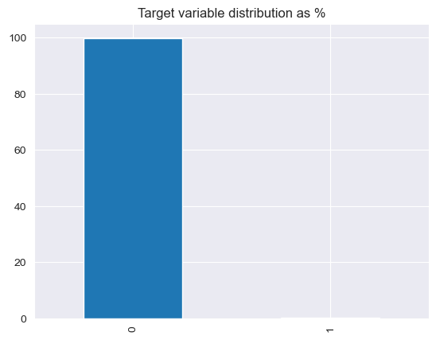

```python
# We check the Dataset distribution around the target variable

isfraud_dist = data_raw['isFraud'].value_counts(normalize=True, dropna=True)*100
print(isfraud_dist)
isfraud_dist.plot(kind='bar', title='Target variable distribution as %')

print('as we can see, target variable is extremely unbalanced so data augmentation may be needed to be implemented.')
```

#### 2.4 Missing values processing

```python
data_raw.isnull().sum()
```

```
step                     0
type                     0
amount                   0
gender              105118
device              104580
connection_time          0
nameOrig                 0
race                105163
oldbalanceOrg            0
age                      0
newbalanceOrig           0
zone                104414
user_number              0
nameDest                 0
user_connections         0
security_alert           0
oldbalanceDest           0
newbalanceDest           0
isFraud                  0
dtype: int64
```

As we can see, we have Nan's values in `gender`, `device`, `race` and `zone`. Theses missing values must be replaced following a justified procedure in order to be able to model our dataset.

#### 2.5 Identification of variables

```python
list_data_cat = dame_variables_categoricas(data_raw)
data_cat = data_raw[data_raw.columns.intersection(list_data_cat)]
data_cat['nameOrig'] = data_raw['nameOrig']
data_cat['nameDest'] = data_raw['nameDest']
list_data_cat.extend(['nameOrig','nameDest'])
print('categorical variables:', list_data_cat)
```

```
categorical variables: ['type', 'gender', 'device', 'race', 'zone', 'security_alert', 'isFraud', 'nameOrig', 'nameDest']
```

```python
list_data_cat
```

```
['type',
 'gender',
 'device',
 'race',
 'zone',
 'security_alert',
 'isFraud',
 'nameOrig',
 'nameDest']
```

```python
list_data_num = dame_variables_numericas(data_raw)
data_num = data_raw[data_raw.columns.intersection(list_data_num)]
print('numerical variables:', list_data_num)
```

```
numerical variables: ['step', 'amount', 'connection_time', 'oldbalanceOrg', 'age', 'newbalanceOrig', 'user_number', 'user_connections', 'oldbalanceDest', 'newbalanceDest']
```

#### 2.6 Outliers

```python
#outliers identification: we set a 1.5x multiplier to check how outliers get identified.

data_outliers = data_raw
data_outliers[list_data_cat] = data_raw[list_data_cat].astype('category')
data_outliers[list_data_num] = data_raw[list_data_num].astype(int)
list_data_outliers = get_deviation_of_mean_perc(data_outliers, list_data_num, target='isFraud', multiplier=1.5)
list_data_outliers = list_data_outliers.loc[:,['variable', 'sum_outlier_values','porcentaje_sum_null_values']]
list_data_outliers
```

|  | variable | sum_outlier_values | porcentaje_sum_null_values |
| --- | --- | --- | --- |
| 0 | step | 22586 | 0.021540 |
| 1 | amount | 45867 | 0.043742 |
| 2 | oldbalanceOrg | 58947 | 0.056216 |
| 3 | age | 131463 | 0.125373 |
| 4 | newbalanceOrig | 59807 | 0.057036 |
| 5 | user_number | 140512 | 0.134003 |
| 6 | user_connections | 209531 | 0.199825 |
| 7 | oldbalanceDest | 57040 | 0.054398 |
| 8 | newbalanceDest | 59187 | 0.056445 |

as we can see, there are outliers but they don't seem to be relevant so far.

#### 2.7 Correlations

**Numerical variables correlations**

In order to look at the correlation between numerical variables, we will use the correlation matrix using the two most common methods, spearman and pearson.

Note: intending to differentiate properly both methods, blues will be used for spearman and greens for pearson.

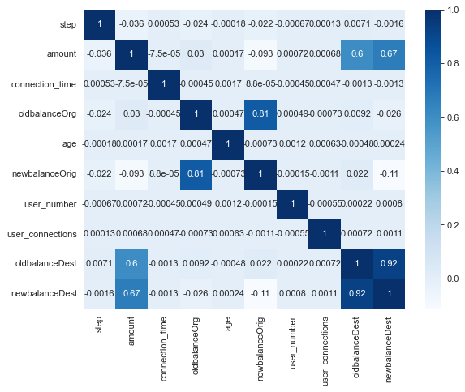

```python
from matplotlib.pyplot import figure
figure(figsize=(8, 6), dpi=80)
corr_matrix = data_num.corr(method='spearman')
sns.heatmap(corr_matrix, annot=True, cmap='Blues')
plt.show()
```

bigger correlations are between the variables that are fundamentally related, as they are the amount of the transactions and the balance of the accounts

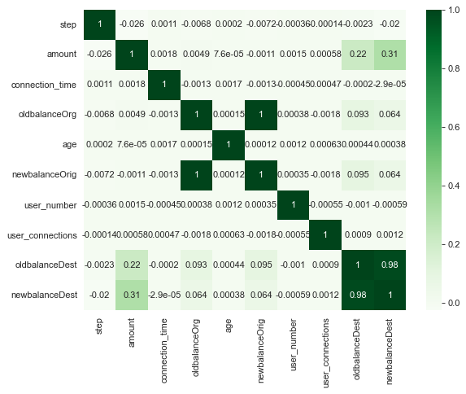

```python
from matplotlib.pyplot import figure
figure(figsize=(8, 6), dpi=80)
corr_matrix = data_num.corr(method='pearson')
sns.heatmap(corr_matrix, annot=True, cmap='Greens')
plt.show()
```

**Categorical variables correlations**

```python
data_cat_cramers = ['type', 'gender', 'device', 'race', 'zone', 'security_alert', 'isFraud']
for i in data_cat_cramers:
    for n in data_cat_cramers:
        if (i!=n):
            if(cramers_V(data_cat[i], data_cat[n])>0.3):
                print(cramers_V(data_cat[i], data_cat[n]), i, ' + ', n)
```

```
0.3253223023579092 device  +  security_alert
0.3253223023579092 security_alert  +  device
```

#### 2.8 Variables representations

Due to the fact that the Dataset is highly unbalanced, We have decided to plot the variables when the Fraud occurs so it can be useful to identify patterns in the cases that analysis gets difficult due to umbalanced dataset.

Note: in boxplots all the data has been used

```python
data_fraud = data_raw[data_raw['isFraud']==1]
data_fraud = data_fraud.reset_index(drop=True)
data_fraud.head()
```

|  | step | type | amount | gender | device | connection_time | nameOrig | race | oldbalanceOrg | age | newbalanceOrig | zone | user_number | nameDest | user_connections | security_alert | oldbalanceDest | newbalanceDest | isFraud |
| --- | --- | --- | --- | --- | --- | --- | --- | --- | --- | --- | --- | --- | --- | --- | --- | --- | --- | --- | --- |
| 0 | 1 | TRANSFER | 181 | man | pc | 0 | C1305486145 | asian | 181 | 66 | 0 | capital | 2569 | C553264065 | 10 | 0 | 0 | 0 | 1 |
| 1 | 1 | CASH_OUT | 181 | man | mac | 0 | C840083671 | black | 181 | 31 | 0 | country | 1787 | C38997010 | 3 | 0 | 21182 | 0 | 1 |
| 2 | 1 | TRANSFER | 2806 | unknow | pc | 0 | C1420196421 | asian | 2806 | 90 | 0 | africa | 1413 | C972765878 | 7 | 0 | 0 | 0 | 1 |
| 3 | 1 | CASH_OUT | 2806 | NaN | mac | 0 | C2101527076 | asian | 2806 | 94 | 0 | capital | 2370 | C1007251739 | 6 | 0 | 26202 | 0 | 1 |
| 4 | 1 | TRANSFER | 20128 | woman | pc | 0 | C137533655 | asian | 20128 | 6 | 0 | country | 3133 | C1848415041 | 3 | 0 | 0 | 0 | 1 |

**Numerical variables representation**

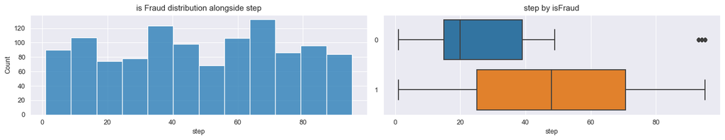

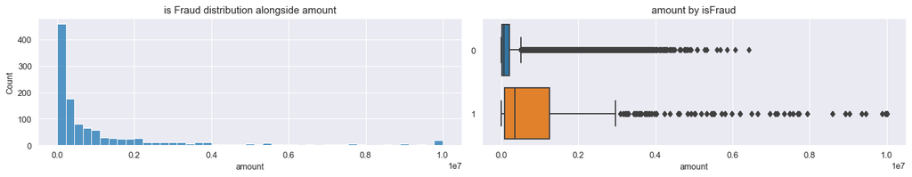

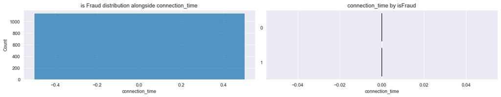

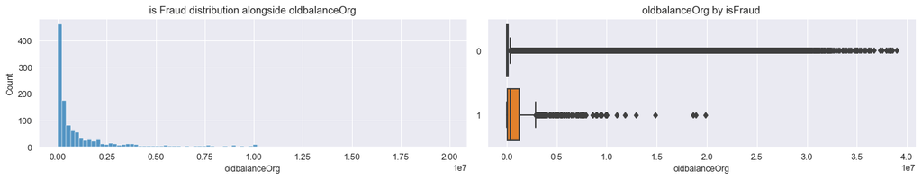

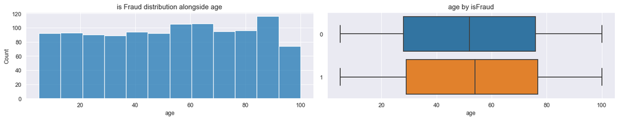

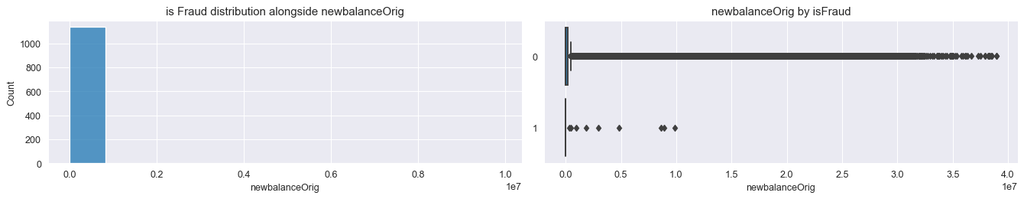

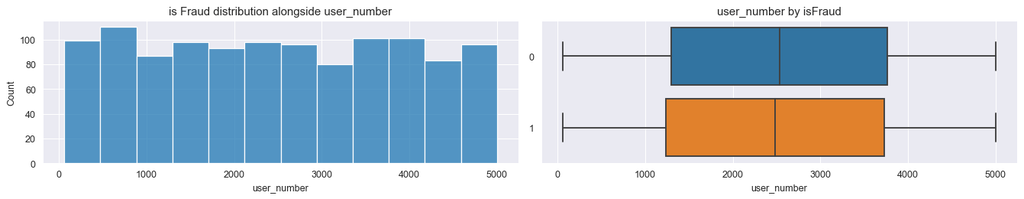

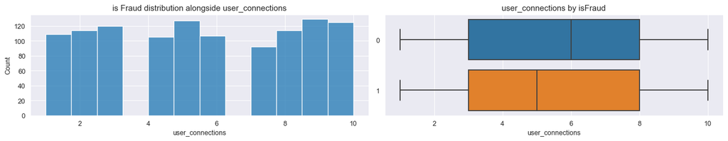

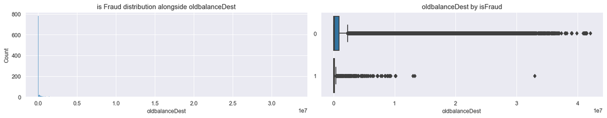

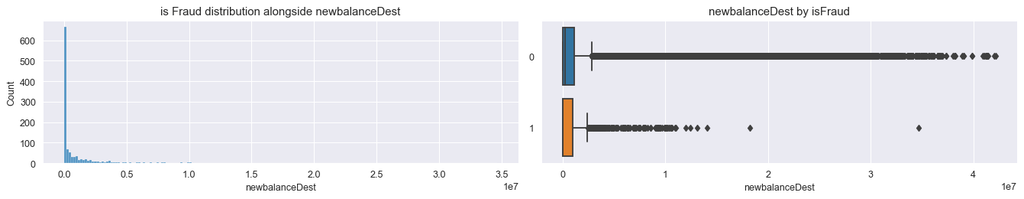

```python
list_num = ['step','amount', 'connection_time','oldbalanceOrg', 'age', 'newbalanceOrig', 'user_number', 'user_connections', 'oldbalanceDest', 'newbalanceDest']
for i in list_num:
    if (i!='isFraud'):
        f, (ax1, ax2) = plt.subplots(nrows=1, ncols=2, figsize=(15,3), dpi=90)
        sns.histplot(data_fraud.loc[data_fraud[i].notnull(), i], kde=False, ax=ax1)
        ax1.set_xlabel(i)
        ax1.set_ylabel('Count')
        ax1.set_title('is Fraud distribution alongside ' + i)
        sns.boxplot(x=i, y='isFraud', data=data_raw, ax=ax2)
        ax2.set_ylabel('')
        ax2.set_title(i + ' by '+'isFraud')
        plt.tight_layout()
    else:
        break
```

Once we have checked the representation of the numerical variables, We can no take important conclussions as the big amount of data makes the analysis difficult. The transactions that are fraudulent and the one that are not seem to be similar at first look.

**Categorical variables representation**

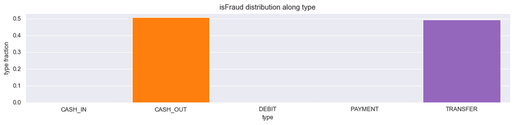

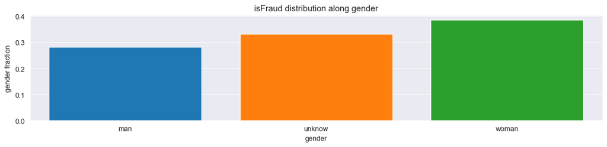

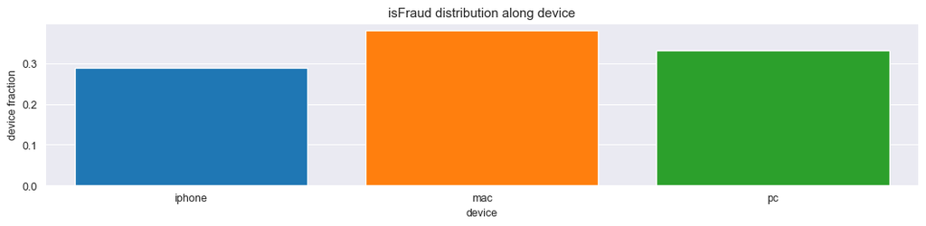

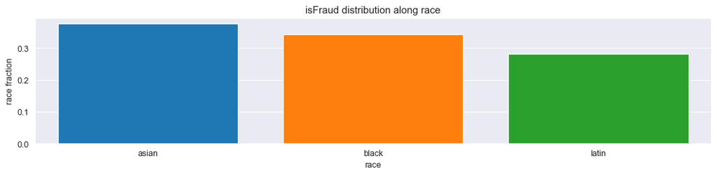

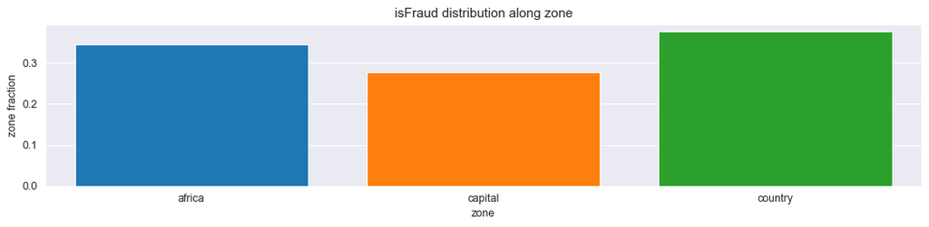

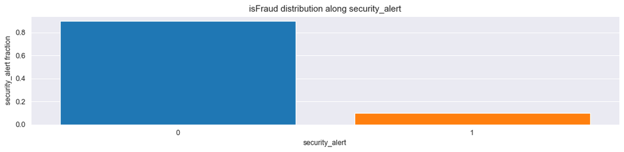

```python
list_cat = ['type', 'gender', 'device', 'race', 'zone', 'security_alert', 'isFraud', 'nameOrig', 'nameDest']
for i in list_cat:
    if (i!='isFraud'):
        f, ax= plt.subplots(nrows=1, ncols=1, figsize=(12,3), dpi=90)
        data = data_fraud[i].value_counts(normalize=True).reset_index()
        data.columns = [i, 'index' ]
        sns.barplot(x = i, y = 'index',  data = data, saturation=1, ax=ax)
        ax.set_ylabel(i + ' fraction')
        ax.set_title('isFraud distribution along ' + i)
        plt.tight_layout()
    else:
        break
```

For the categorical variables We have only chosen the Fraudulent transactions in order to analyse their distribution. They seem to be equally distributed for most of the variables, except for `type` and `security_alert` variables. It's important to highlight that most of the fraudulent transactions did not have a security alert, which apparently should not happen.

# 3. Objectives To Model

In this part we will choose the variables to be used and to transform our dataset in order to start the modeling.

#### 3.1 Variable transformation.

The variables `nameOrig` and `nameDest` are ID's of the accounts involved in the transactions, therefore, they are no relevant in forecasting. Nevertheless, their syntaxis may be important because they contain letters C to M that describes their type of account, being 'C' Client account and 'M' Merchant account, and that information may be useful to analyse if Fraud happens in any kind of specific transacction.

```python
data_raw["transaction_type"] = np.nan

# filling feature column
data_raw.loc[data_raw.nameOrig.str.contains('C') & data_raw.nameDest.str.contains('C'), "transaction_type"] = "CC"
data_raw.loc[data_raw.nameOrig.str.contains('C') & data_raw.nameDest.str.contains('M'), "transaction_type"] = "CM"
data_raw.loc[data_raw.nameOrig.str.contains('M') & data_raw.nameDest.str.contains('C'), "transaction_type"] = "MC"
data_raw.loc[data_raw.nameOrig.str.contains('M') & data_raw.nameDest.str.contains('M'), "transaction_type"] = "MM"
```

```python
print("Transactions with no kind of fraud: \n",data_raw[data_raw["isFraud"] == 0].transaction_type.value_counts())
print("\n Transactions containing fraud: \n",data_raw[data_raw["isFraud"] == 1].transaction_type.value_counts())
```

```
Transactions with no kind of fraud:
 CC    693560
CM    353873
Name: transaction_type, dtype: int64

 Transactions containing fraud:
 CC    1142
Name: transaction_type, dtype: int64
```

As we can see, the 100% of the Frauds have happened in Client-to-Client transacctions, so we will use that information in our modeling. Therefore, columns `nameOrig` and `nameDest` and `user_number` are no longer needed as transaction_type summarise their information.

```python
data_raw = data_raw.drop(['nameDest', 'nameOrig', 'user_number'], axis=1)
```

#### 3.2 Missing values transformation

> Zone variable

```python
data_raw['zone'].value_counts(normalize=True, dropna=False)*100
```

```
country    35.095630
africa     29.947882
capital    24.998784
NaN         9.957705
Name: zone, dtype: float64
```

As we can no estimate the zone we will susbtitute it for the value 'unknown' because we believe that changing it for any recorded value ('country', 'africa' or capital) would skew the dataset.

```python
data_raw['zone'] = data_raw['zone'].astype(object).fillna('zone_unknown')
```

> Device variable

```python
data_raw['device'].value_counts(normalize=True, dropna=False)*100
```

```
mac       35.006175
pc        30.028086
iphone    24.992204
NaN        9.973536
Name: device, dtype: float64
```

We repeat the process with 'device' variable because we don't know if the NaN values are due to a lack of information about the device or because the system does not record any system which is not either a mac, a pc or an iphone.

```python
data_raw['device'] = data_raw['device'].astype(object).fillna('other/unknown_device')
```

> Gender variable

```python
# there's a typo in this column regarding the row-value 'unknown' so we correct it to proceed with the analysis.
data_raw = data_raw.astype(object).assign(**{'gender': lambda df: df['gender'].replace({
    'unknow': 'gender_unknown'})})
```

```python
gender_dist = data_raw['gender'].value_counts(normalize=True, dropna=True)*100
gender_dist
```

```
woman             38.889531
gender_unknown    33.314396
man               27.796073
Name: gender, dtype: float64
```

For the Gender variable, we will apply a different method. Since every new entry should fit one of the three choices, we will allocate the Nan's with these three kinds following the distribution they have if we don't count the NaN's values.

```python
nans = data_raw['gender'].isna()
length = sum(nans)
data_raw['gender'][data_raw['gender'].isna()] = random.choices(['woman', 'gender_unknown', 'man'], weights=[gender_dist.iloc[0], gender_dist.iloc[1], gender_dist.iloc[2]], k=length)
```

> Race variable

Finally, we have decided to drop the Race variable becuase of its nature. We consider that it's not correct to create a profile taking into account the race of the individual.

```python
data_raw = data_raw.drop(['race'], axis=1)
```

#### 3.3 Categorical variables encoding

now we have to encode categorical variables using numerical preprocessing, with the following schema:

- `type`, `gender`, `device`, `zone`, `transaction_type` = one hot encoding, as the number of variables and the number of different values is small enough to apply one hot encoder.

```python
# We create a new variable for the processed data
data = data_raw
```

```python
ohe = OneHotEncoder()
data_ohe = data[['type', 'gender', 'device', 'zone', 'transaction_type']]
for i in data_ohe.columns:
    oh_array = ohe.fit_transform(data[i].values.reshape(-1,1)).toarray()
    oh_data = pd.DataFrame(oh_array, columns=data[i].unique())
    data = pd.concat([data, oh_data], axis=1)
    data = data.drop([i], axis=1)
```

```python
data.head()
```

|  | step | amount | connection_time | oldbalanceOrg | age | newbalanceOrig | user_connections | security_alert | oldbalanceDest | newbalanceDest | ... | mac | pc | iphone | other/unknown_device | capital | country | africa | zone_unknown | CM | CC |
| --- | --- | --- | --- | --- | --- | --- | --- | --- | --- | --- | --- | --- | --- | --- | --- | --- | --- | --- | --- | --- | --- |
| 0 | 1 | 9839 | 0 | 170136 | 85 | 160296 | 5 | 1 | 0 | 0 | ... | 0.0 | 1.0 | 0.0 | 0.0 | 0.0 | 1.0 | 0.0 | 0.0 | 0.0 | 1.0 |
| 1 | 1 | 1864 | 0 | 21249 | 57 | 19384 | 1 | 0 | 0 | 0 | ... | 0.0 | 1.0 | 0.0 | 0.0 | 0.0 | 0.0 | 1.0 | 0.0 | 0.0 | 1.0 |
| 2 | 1 | 181 | 0 | 181 | 66 | 0 | 10 | 0 | 0 | 0 | ... | 0.0 | 0.0 | 0.0 | 1.0 | 0.0 | 1.0 | 0.0 | 0.0 | 1.0 | 0.0 |
| 3 | 1 | 181 | 0 | 181 | 31 | 0 | 3 | 0 | 21182 | 0 | ... | 0.0 | 1.0 | 0.0 | 0.0 | 0.0 | 0.0 | 1.0 | 0.0 | 1.0 | 0.0 |
| 4 | 1 | 11668 | 0 | 41554 | 90 | 29885 | 8 | 0 | 0 | 0 | ... | 0.0 | 1.0 | 0.0 | 0.0 | 0.0 | 0.0 | 1.0 | 0.0 | 0.0 | 1.0 |

5 rows × 29 columns

Finally, we transform the already binary categories (`security_alert` & `isFraud`) to integer

```python
data['security_alert'] = data['security_alert'].astype(int)
data['isFraud'] = data['isFraud'].astype(int)
```

```python
data = data.reindex(columns = [col for col in data.columns if col != 'isFraud'] + ['isFraud'])
```

```python
# We allocate the processed data into our directory in order to access to it easier.
##from pathlib import Path
##filepath = Path('C:/Users/drive/Documents/MASTER/MACHINE_LEARNING/FRAUD/data/processed/Original_dataset_payments_fraud_processed.csv')
##filepath.parent.mkdir(parents=True, exist_ok=True)
##data.to_csv(filepath, index=False)
```

# 4. For the target variable (Modeling).

First of all, we have to check which kind of distribution our dataset follows. In order to do so, we will carry out a Shapiro-Wilk test.

The Shapiro-Wilk test takes `data`(processed dataset) as input, and return the statistic and the p-value. If the p-value is below the confidence interval (1-0.95) we reject the null hypothesis and we accept that the data **does not** follow a normal distribution.

```python
from scipy import stats
shapiro_test = stats.shapiro(data)

print(shapiro_test)
if shapiro_test[1]<0.05:
    print('p-value:', shapiro_test[1], ', null hypothesis is rejected so we can claim that the Dataset does not follow a normal distribution')
else:
    print('p-value:', shapiro_test[1], ', null hypothesis is accepted so we can claim that the Dataset follows a normal distribution')
```

```
ShapiroResult(statistic=0.1227790117263794, pvalue=0.0)
p-value: 0.0 , null hypothesis is rejected so we can claim that the Dataset does not follow a normal distribution
```

#### 4.1 Splitting into Train & Test

We will use K-Folds cross-validator.

It provides train/test indices to split data in train/test sets. Split dataset into k consecutive folds (without shuffling by default).

Each fold is then used once as a validation while the k - 1 remaining folds form the training set.

```python
X = data.iloc[:,:-1]
y = data.iloc[:,-1:]

np_X = np.array(X)
np_y = np.array(y)

kf = KFold(n_splits=7)
kf.get_n_splits(np_X)

print(kf)
KFold(n_splits=7, random_state=None, shuffle=False)
for train_index, test_index in kf.split(np_X):
    print('TRAIN', train_index, 'TEST', test_index)
    X_train, X_test = np_X[train_index], np_X[test_index]
    y_train, y_test = np_y[train_index], np_y[test_index]
```

```
KFold(n_splits=7, random_state=None, shuffle=False)
TRAIN [ 149797  149798  149799 ... 1048572 1048573 1048574] TEST [     0      1      2 ... 149794 149795 149796]
TRAIN [      0       1       2 ... 1048572 1048573 1048574] TEST [149797 149798 149799 ... 299591 299592 299593]
TRAIN [      0       1       2 ... 1048572 1048573 1048574] TEST [299594 299595 299596 ... 449388 449389 449390]
TRAIN [      0       1       2 ... 1048572 1048573 1048574] TEST [449391 449392 449393 ... 599184 599185 599186]
TRAIN [      0       1       2 ... 1048572 1048573 1048574] TEST [599187 599188 599189 ... 748980 748981 748982]
TRAIN [      0       1       2 ... 1048572 1048573 1048574] TEST [748983 748984 748985 ... 898776 898777 898778]
TRAIN [     0      1      2 ... 898776 898777 898778] TEST [ 898779  898780  898781 ... 1048572 1048573 1048574]
```

Now we transform the arrays into DataFrames and we change columns' names.

```python
X_train = pd.DataFrame(X_train)
X_test = pd.DataFrame(X_test)
X_test.columns = data.columns[:-1]
X_train.columns = data.columns[:-1]
X_train.head()
```

|  | step | amount | connection_time | oldbalanceOrg | age | newbalanceOrig | user_connections | security_alert | oldbalanceDest | newbalanceDest | ... | mac | pc | iphone | other/unknown_device | capital | country | africa | zone_unknown | CM | CC |
| --- | --- | --- | --- | --- | --- | --- | --- | --- | --- | --- | --- | --- | --- | --- | --- | --- | --- | --- | --- | --- | --- |
| 0 | 1 | 9839 | 0 | 170136 | 85 | 160296 | 5 | 1 | 0 | 0 | ... | 0.0 | 1.0 | 0.0 | 0.0 | 0.0 | 1.0 | 0.0 | 0.0 | 0.0 | 1.0 |
| 1 | 1 | 1864 | 0 | 21249 | 57 | 19384 | 1 | 0 | 0 | 0 | ... | 0.0 | 1.0 | 0.0 | 0.0 | 0.0 | 0.0 | 1.0 | 0.0 | 0.0 | 1.0 |
| 2 | 1 | 181 | 0 | 181 | 66 | 0 | 10 | 0 | 0 | 0 | ... | 0.0 | 0.0 | 0.0 | 1.0 | 0.0 | 1.0 | 0.0 | 0.0 | 1.0 | 0.0 |
| 3 | 1 | 181 | 0 | 181 | 31 | 0 | 3 | 0 | 21182 | 0 | ... | 0.0 | 1.0 | 0.0 | 0.0 | 0.0 | 0.0 | 1.0 | 0.0 | 1.0 | 0.0 |
| 4 | 1 | 11668 | 0 | 41554 | 90 | 29885 | 8 | 0 | 0 | 0 | ... | 0.0 | 1.0 | 0.0 | 0.0 | 0.0 | 0.0 | 1.0 | 0.0 | 0.0 | 1.0 |

5 rows × 28 columns

```python
# We change the types of the variable from object to float so it can be easily interpretable for the models.
for i in X_test.columns:
    X_test[i] = X_test[i].astype(float)

X_test.dtypes
```

```
step                    float64
amount                  float64
connection_time         float64
oldbalanceOrg           float64
age                     float64
newbalanceOrig          float64
user_connections        float64
security_alert          float64
oldbalanceDest          float64
newbalanceDest          float64
PAYMENT                 float64
TRANSFER                float64
CASH_OUT                float64
DEBIT                   float64
CASH_IN                 float64
man                     float64
woman                   float64
gender_unknown          float64
mac                     float64
pc                      float64
iphone                  float64
other/unknown_device    float64
capital                 float64
country                 float64
africa                  float64
zone_unknown            float64
CM                      float64
CC                      float64
dtype: object
```

```python
y_train = pd.DataFrame(y_train)
y_test = pd.DataFrame(y_test)
y_test.columns = data.columns[-1:]
y_train.columns = data.columns[-1:]
y_train.head()
```

|  | isFraud |
| --- | --- |
| 0 | 0 |
| 1 | 0 |
| 2 | 1 |
| 3 | 1 |
| 4 | 0 |

#### 4.2 Data Augmentation: Smote

We will apply SMOTE (Data Augmentation) to our Dataset with the purpose of balance the dataset around 80/20 in order to have enough information for the models

```
isFraud
0          80.000053
1          19.999947
dtype: float64
```

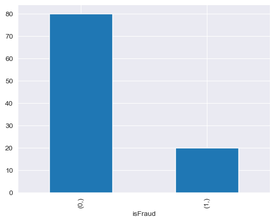

```python
from imblearn.over_sampling import SMOTE

smt = SMOTE(sampling_strategy=0.25)
X_train_smt, y_train_smt = smt.fit_resample(X_train, y_train)

isfraud_smt_dist = y_train_smt.value_counts(normalize=True)*100
print(isfraud_smt_dist)
isfraud_smt_dist.plot(kind='bar')
```

#### 4.3 Data Scaling: MinMax Scaler

As we have identified our Dataset distribution as non-normal, we will use a min-max scaler for our Data instead of a Standard scaler.

```python
from sklearn.preprocessing import MinMaxScaler
# We save original X_test, so it can be analysed later with original value
scaler = MinMaxScaler()
X_train_smt = pd.DataFrame(scaler.fit_transform(X_train_smt))
X_test =pd.DataFrame(scaler.fit_transform(X_test))
X_test.columns = X_train.columns
X_train_smt.columns = X_train.columns
```

#### 4.4 Models

#### Linear model

As a linear model We have used DummyClassifier that makes predictions that ignore the input features.

This classifier serves as a simple baseline to compare against other more complex classifiers.

```python
from sklearn.dummy import DummyClassifier

model = DummyClassifier(strategy="most_frequent")
training = model.fit(X_train_smt, y_train_smt)
print(training)
# Model saving.
joblib.dump(training, '../models/dummy_classifier.pkl')
```

```
DummyClassifier(strategy='most_frequent')
```

```
['../models/dummy_classifier.pkl']
```

```
              precision    recall  f1-score   support

           0       1.00      1.00      1.00    149150
           1       0.00      0.00      0.00       646

    accuracy                           1.00    149796
   macro avg       0.50      0.50      0.50    149796
weighted avg       0.99      1.00      0.99    149796
```

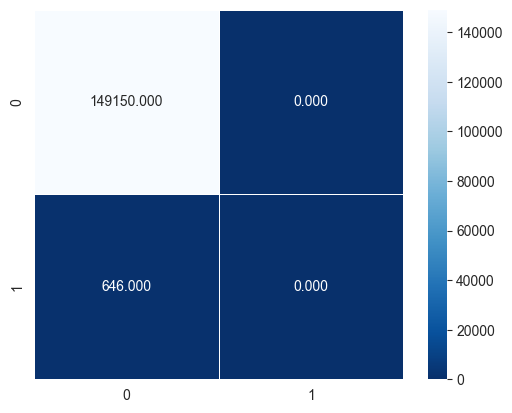

```python
# Predictions, we have load the joblib so we do not need to re-fit the model once we re-open the notebook
model = joblib.load('../models/dummy_classifier.pkl')
predictions = model.predict(X_test)

conf_matrix = confusion_matrix(y_test, predictions)
print(classification_report(y_test, predictions))
matriz_confusion(conf_matrix)
```

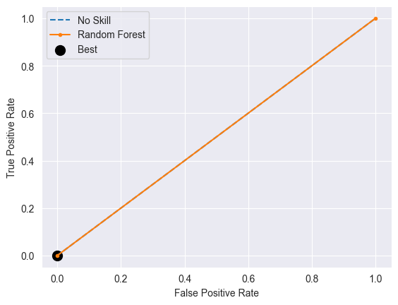

```python
y_prob = model.predict_proba(X_test)
y_hat = y_prob[:, 1]
fpr, tpr, thresholds = roc_curve(y_test, y_hat)
plt.plot([0, 1], [0, 1], linestyle='--', label='No Skill')
plt.plot(fpr, tpr, marker='.', label='Random Forest')
gmeans = np.sqrt(tpr * (1-fpr))
ix = np.argmax(gmeans)
plt.scatter(fpr[ix], tpr[ix], s=100, marker='o', color='black', label='Best')
# axis labels
plt.xlabel('False Positive Rate')
plt.ylabel('True Positive Rate')
plt.legend()
# show the plot
plt.show()
```

Neither the confusion matrix nor the ROC curve gives any relevant information in this case since the Dummy Classification does not realize any prediction.

#### Regression + Lasso

being penalty 'l1' Lasso regularization that penalise the sum of the absolute value of the regression coefficients. Lasso Regression (Least Absolute Shrinkage and Selection Operator) adds “absolute value of magnitude” of coefficient as penalty term to the loss function.

```python
from sklearn.linear_model import LogisticRegression

penalty='l1'
model = LogisticRegression(penalty=penalty, random_state=0, solver='liblinear')
training = model.fit(X_train_smt, y_train_smt)
print(training)
# Model saving.
joblib.dump(training, '../models/logistic_lasso.pkl')
```

```
LogisticRegression(penalty='l1', random_state=0, solver='liblinear')
```

```
['../models/logistic_lasso.pkl']
```

```
              precision    recall  f1-score   support

           0       1.00      0.96      0.98    149150
           1       0.08      0.94      0.15       646

    accuracy                           0.96    149796
   macro avg       0.54      0.95      0.57    149796
weighted avg       1.00      0.96      0.97    149796
```

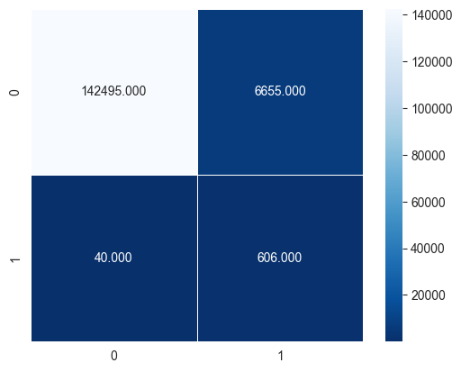

```python
# Predictions, we have load the joblib, so we do not need to re-fit the model once we re-open the notebook
model = joblib.load('../models/logistic_lasso.pkl')
predictions = model.predict(X_test)

conf_matrix = confusion_matrix(y_test, predictions)
print(classification_report(y_test, predictions))
matriz_confusion(conf_matrix)
```

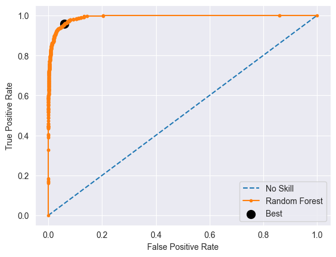

```python
y_prob = model.predict_proba(X_test)
y_hat = y_prob[:, 1]
fpr, tpr, thresholds = roc_curve(y_test, y_hat)
plt.plot([0, 1], [0, 1], linestyle='--', label='No Skill')
plt.plot(fpr, tpr, marker='.', label='Random Forest')
gmeans = np.sqrt(tpr * (1-fpr))
ix = np.argmax(gmeans)
plt.scatter(fpr[ix], tpr[ix], s=100, marker='o', color='black', label='Best')
# axis labels
plt.xlabel('False Positive Rate')
plt.ylabel('True Positive Rate')
plt.legend()
# show the plot
plt.show()
```

Although the ROC curve could interpretate the model as good for predictions, the truth is that once we look at the scores we see a poor f1-score for the '1' label, and an equally poor precision value, with a high amount of False Positive rate. In this case we can affirm that the model is not a good predictor.

#### Generalized Linear Models (GLM)

We treat it as a standard linear model with l2 regularization technique, known as Ridge Regression that adds “squared magnitude” of coefficient as penalty term to the loss function.

```python
penalty='l2'
model = LogisticRegression(penalty=penalty, random_state=0, solver='liblinear')
training = model.fit(X_train_smt, y_train_smt)
print(training)
# Model saving.
joblib.dump(training, '../models/GLM.pkl')
```

```
LogisticRegression(random_state=0, solver='liblinear')
```

```
['../models/GLM.pkl']
```

```
              precision    recall  f1-score   support

           0       1.00      0.96      0.98    149150
           1       0.08      0.78      0.15       646

    accuracy                           0.96    149796
   macro avg       0.54      0.87      0.56    149796
weighted avg       1.00      0.96      0.98    149796

model score on training data: 0.9106294412536636
model score on testing data: 0.9605663702635584
```

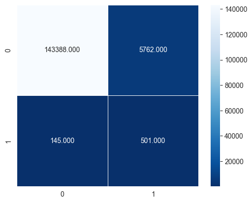

```python
model = joblib.load('../models/GLM.pkl')
predictions = model.predict(X_test)

conf_matrix = confusion_matrix(y_test, predictions)
print(classification_report(y_test, predictions))
matriz_confusion(conf_matrix)
print(f'model score on training data: {model.score(X_train_smt, y_train_smt)}')
print(f'model score on testing data: {model.score(X_test, y_test)}')
```

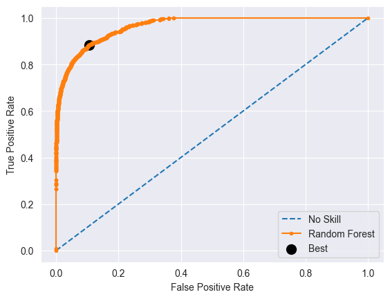

```python
y_prob = model.predict_proba(X_test)
y_hat = y_prob[:, 1]
fpr, tpr, thresholds = roc_curve(y_test, y_hat)
plt.plot([0, 1], [0, 1], linestyle='--', label='No Skill')
plt.plot(fpr, tpr, marker='.', label='Random Forest')
gmeans = np.sqrt(tpr * (1-fpr))
ix = np.argmax(gmeans)
plt.scatter(fpr[ix], tpr[ix], s=100, marker='o', color='black', label='Best')
# axis labels
plt.xlabel('False Positive Rate')
plt.ylabel('True Positive Rate')
plt.legend()
# show the plot
plt.show()
```

For the GLM the metric are worse than Regression + Lasso. If we look at the confusion matrix, we will se that the number of False Negatives have increased and the ROC curve returns worse values as well. This model can't be considered.

#### Support Vector Machine (SVM)

```python
# Original SVM took one day to compute

from sklearn.linear_model import SGDClassifier
from sklearn.calibration import CalibratedClassifierCV

model = SGDClassifier(random_state=0, loss="hinge")
training = model.fit(X_train_smt,y_train_smt)
calibrator = CalibratedClassifierCV(training, cv='prefit').fit(X_train_smt, y_train_smt)
print(calibrator)
# model saving
joblib.dump(calibrator, '../models/SVM.pkl')
```

```
CalibratedClassifierCV(base_estimator=SGDClassifier(random_state=0),
                       cv='prefit')
```

```
['../models/SVM.pkl']
```

```
              precision    recall  f1-score   support

           0       1.00      0.93      0.96    149150
           1       0.04      0.59      0.07       646

    accuracy                           0.93    149796
   macro avg       0.52      0.76      0.52    149796
weighted avg       0.99      0.93      0.96    149796

model score on training data: 0.8535462789875433
model score on testing data: 0.9282891398969265
```

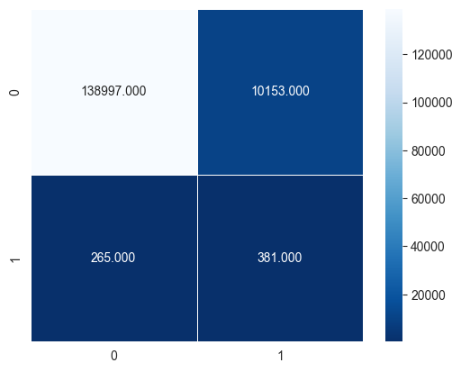

```python
calibrator = joblib.load('../models/SVM.pkl')
predictions = calibrator.predict(X_test)
conf_matrix = confusion_matrix(y_test, predictions)
print(classification_report(y_test, predictions))
matriz_confusion(conf_matrix)
print(f'model score on training data: {model.score(X_train_smt, y_train_smt)}')
print(f'model score on testing data: {model.score(X_test, y_test)}')
```

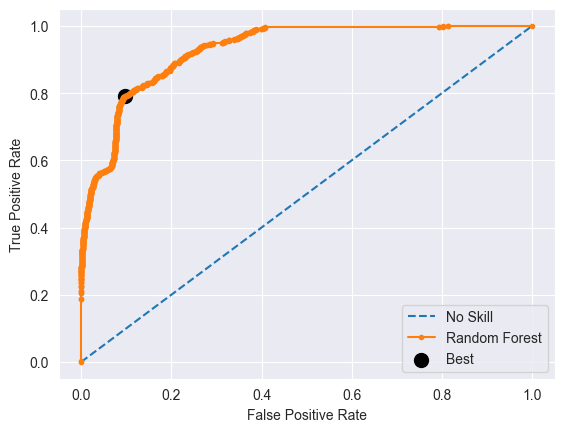

```python
y_prob = calibrator.predict_proba(X_test)
y_hat = y_prob[:, 1]
fpr, tpr, thresholds = roc_curve(y_test, y_hat)
plt.plot([0, 1], [0, 1], linestyle='--', label='No Skill')
plt.plot(fpr, tpr, marker='.', label='Random Forest')
gmeans = np.sqrt(tpr * (1-fpr))
ix = np.argmax(gmeans)
plt.scatter(fpr[ix], tpr[ix], s=100, marker='o', color='black', label='Best')
# axis labels
plt.xlabel('False Positive Rate')
plt.ylabel('True Positive Rate')
plt.legend()
# show the plot
plt.show()
```

The objective of the support vector machine algorithm is to find a hyperplane in an N-dimensional space(N — the number of features) that distinctly classifies the data points. Apparently, in this case is not optimal since the metrics are still not good enough for predictions, with too high values of False Negatives.

#### Random Forest Classifier

```python
model = RandomForestClassifier()
training = model.fit(X_train_smt, y_train_smt)
# model saving
joblib.dump(training, '../models/random_forest.pkl')
```

```
['../models/random_forest.pkl']
```

```
Mean Cross-Validation score: 0.96
              precision    recall  f1-score   support

           0       1.00      1.00      1.00    149150
           1       0.85      0.62      0.72       646

    accuracy                           1.00    149796
   macro avg       0.92      0.81      0.86    149796
weighted avg       1.00      1.00      1.00    149796
```

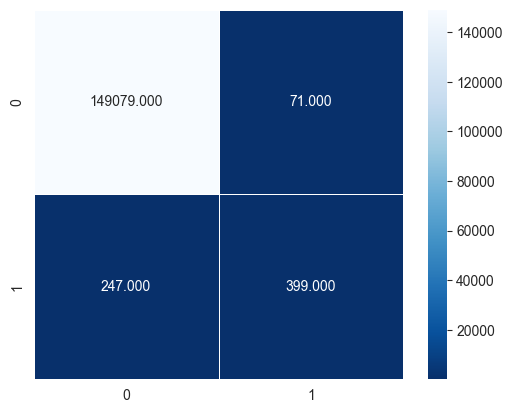

```python
model = joblib.load('../models/random_forest.pkl')
predictions =  model.predict(X_test)
conf_matrix = confusion_matrix(y_test, predictions)
scores_training = cross_val_score(model, X_train_smt, y_train_smt, cv=5)
print('Mean Cross-Validation score: %.2f' % scores_training.mean())

print(classification_report(y_test, predictions))
matriz_confusion(conf_matrix)
```

```
model score on training data: 1.0
model score on testing data: 0.997877112873508
```

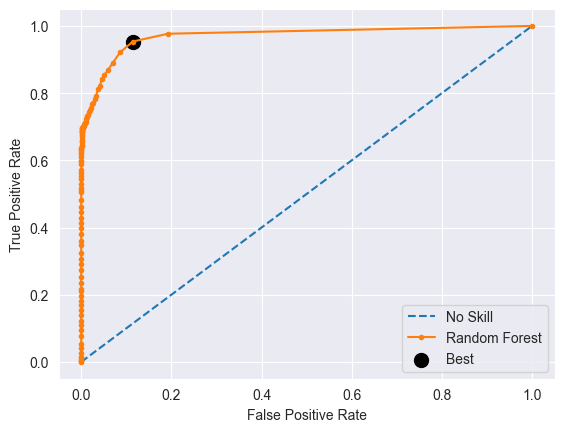

```python
print(f'model score on training data: {model.score(X_train_smt, y_train_smt)}')
print(f'model score on testing data: {model.score(X_test, y_test)}')
y_prob = model.predict_proba(X_test)
y_hat = y_prob[:, 1]
fpr, tpr, thresholds = roc_curve(y_test, y_hat)
plt.plot([0, 1], [0, 1], linestyle='--', label='No Skill')
plt.plot(fpr, tpr, marker='.', label='Random Forest')
gmeans = np.sqrt(tpr * (1-fpr))
ix = np.argmax(gmeans)
plt.scatter(fpr[ix], tpr[ix], s=100, marker='o', color='black', label='Best')
# axis labels
plt.xlabel('False Positive Rate')
plt.ylabel('True Positive Rate')
plt.legend()
# show the plot
plt.show()
```

In this case, the model returns good metrics that imply the well-functioning of the model. Even though, the number of False Negatives is still high so other models must be taken into account. The good point is that the number of False positive is low.